← Back to index

# 3.3.5 Sensor Fusion: Autonomous Vehicle Localization

This notebook illustrates **sensor fusion** from Chapter 3.3.5 using a real-world scenario: estimating the position of an autonomous vehicle using multiple heterogeneous sensors with different noise characteristics.

## The Problem

An autonomous vehicle needs to know its precise location. It has three different sensors:

1. **GPS**: Good overall accuracy but affected by atmospheric conditions and multipath effects
2. **LiDAR-based localization**: Very accurate in measuring distance to landmarks, but less accurate laterally
3. **Camera-based visual odometry**: Good at tracking lateral movement (lane lines), but depth estimation is noisy

Each sensor provides a noisy estimate of the vehicle's 2D position $(x, y)$, but with different error characteristics. How do we optimally combine these measurements?

```python
import numpy as np
import matplotlib.pyplot as plt
from matplotlib.patches import Ellipse
import matplotlib.transforms as transforms
from scipy import linalg

np.random.seed(42)

# Set up nice plotting defaults
plt.rcParams['figure.figsize'] = [10, 8]
plt.rcParams['font.size'] = 12
```

## Mathematical Background: Sensor Fusion

From Section 3.3.5, when we have $M$ sensors each providing measurements of an unknown state $\mathbf{z}$, the model is:

$$p(\mathbf{z}, \mathbf{y}) = p(\mathbf{z}) \prod_{m=1}^{M} \prod_{n=1}^{N_m} \mathcal{N}(\mathbf{y}_{n,m} | \mathbf{z}, \boldsymbol{\Sigma}_m)$$

where:

- $\mathbf{z} \in \mathbb{R}^D$ is the true (unknown) position
- $\mathbf{y}_{n,m}$ is the $n$-th observation from sensor $m$
- $\boldsymbol{\Sigma}_m$ is the noise covariance of sensor $m$

### Bayes Rule for Gaussians

Using **Bayes rule for Gaussians** (Equation 3.37), the posterior is:

$$p(\mathbf{z}|\mathbf{y}) = \mathcal{N}(\mathbf{z}|\boldsymbol{\mu}_{z|y}, \boldsymbol{\Sigma}_{z|y})$$

where: $$\boldsymbol{\Sigma}_{z|y}^{-1} = \boldsymbol{\Sigma}_z^{-1} + \sum_{m=1}^{M} N_m \boldsymbol{\Sigma}_m^{-1}$$

$$\boldsymbol{\mu}_{z|y} = \boldsymbol{\Sigma}_{z|y} \left[ \boldsymbol{\Sigma}_z^{-1} \boldsymbol{\mu}_z + \sum_{m=1}^{M} \boldsymbol{\Sigma}_m^{-1} (N_m \bar{\mathbf{y}}_m) \right]$$

**Key insight**: The posterior precision (inverse covariance) is the sum of individual precisions. More reliable sensors (lower variance = higher precision) contribute more to the final estimate.

## Setting Up the Scenario

Let's define our three sensors with realistic noise characteristics:

- **GPS**: Isotropic noise (equal in all directions), moderate accuracy
- **LiDAR**: Very accurate in the forward direction (x), less accurate laterally (y)
- **Camera**: Accurate laterally (y, from lane detection), poor depth estimation (x)

```python
# True vehicle position (unknown to the sensors)
z_true = np.array([10.0, 5.0])  # True position in meters

# Sensor noise covariance matrices
# GPS: isotropic noise, sigma = 2m in each direction
Sigma_gps = np.array([[4.0, 0.0],
                      [0.0, 4.0]])

# LiDAR: very accurate in x (forward), less accurate in y (lateral)
# Also has some correlation due to scan geometry
Sigma_lidar = np.array([[0.25, 0.1],
                        [0.1, 1.0]])

# Camera: poor depth (x), good lateral (y) from lane detection
Sigma_camera = np.array([[2.5, -0.2],
                         [-0.2, 0.16]])

# Prior: we have a rough idea where the vehicle is (from previous estimate)
mu_prior = np.array([9.0, 6.0])  # Prior mean
Sigma_prior = np.array([[9.0, 0.0],   # Prior covariance (fairly uncertain)
                        [0.0, 9.0]])

print("Sensor Noise Standard Deviations:")
print(f"GPS: sigma_x = {np.sqrt(Sigma_gps[0,0]):.2f}m, sigma_y = {np.sqrt(Sigma_gps[1,1]):.2f}m")
print(f"LiDAR: sigma_x = {np.sqrt(Sigma_lidar[0,0]):.2f}m, sigma_y = {np.sqrt(Sigma_lidar[1,1]):.2f}m")
print(f"Camera: sigma_x = {np.sqrt(Sigma_camera[0,0]):.2f}m, sigma_y = {np.sqrt(Sigma_camera[1,1]):.2f}m")
```

```
Sensor Noise Standard Deviations:
GPS: sigma_x = 2.00m, sigma_y = 2.00m
LiDAR: sigma_x = 0.50m, sigma_y = 1.00m
Camera: sigma_x = 1.58m, sigma_y = 0.40m
```

## Generating Sensor Measurements

Each sensor takes multiple measurements. We'll simulate realistic scenarios where some sensors might have more readings than others.

```python
def generate_measurements(z_true, Sigma, n_measurements):
    """Generate n noisy measurements from a sensor with covariance Sigma."""
    return np.random.multivariate_normal(z_true, Sigma, n_measurements)

# Number of measurements from each sensor
n_gps = 5      # GPS updates at ~5 Hz
n_lidar = 10   # LiDAR scans at ~10 Hz
n_camera = 15  # Camera runs at ~15 Hz

# Generate measurements
y_gps = generate_measurements(z_true, Sigma_gps, n_gps)
y_lidar = generate_measurements(z_true, Sigma_lidar, n_lidar)
y_camera = generate_measurements(z_true, Sigma_camera, n_camera)

# Compute sample means
y_bar_gps = y_gps.mean(axis=0)
y_bar_lidar = y_lidar.mean(axis=0)
y_bar_camera = y_camera.mean(axis=0)

print("Sample means (estimates from each sensor):")
print(f"True position: ({z_true[0]:.2f}, {z_true[1]:.2f})")
print(f"GPS mean ({n_gps} samples): ({y_bar_gps[0]:.2f}, {y_bar_gps[1]:.2f})")
print(f"LiDAR mean ({n_lidar} samples): ({y_bar_lidar[0]:.2f}, {y_bar_lidar[1]:.2f})")
print(f"Camera mean ({n_camera} samples): ({y_bar_camera[0]:.2f}, {y_bar_camera[1]:.2f})")
```

```
Sample means (estimates from each sensor):
True position: (10.00, 5.00)
GPS mean (5 samples): (10.81, 5.98)
LiDAR mean (10 samples): (9.67, 4.57)
Camera mean (15 samples): (10.18, 4.94)
```

## Visualizing Individual Sensor Measurements

Let's visualize the measurements from each sensor along with their uncertainty ellipses.

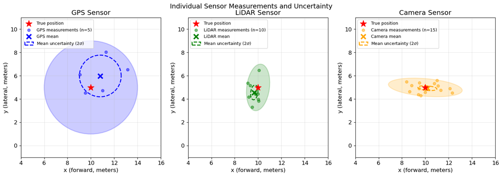

```python
def plot_covariance_ellipse(ax, mean, cov, n_std=2.0, **kwargs):
    """
    Plot an ellipse representing the covariance matrix.
    n_std: number of standard deviations for the ellipse radius
    """
    # Eigenvalue decomposition
    eigenvalues, eigenvectors = linalg.eigh(cov)

    # Sort by eigenvalue (largest first)
    order = eigenvalues.argsort()[::-1]
    eigenvalues = eigenvalues[order]
    eigenvectors = eigenvectors[:, order]

    # Calculate angle
    angle = np.degrees(np.arctan2(eigenvectors[1, 0], eigenvectors[0, 0]))

    # Width and height are 2 * n_std * sqrt(eigenvalue)
    width = 2 * n_std * np.sqrt(eigenvalues[0])
    height = 2 * n_std * np.sqrt(eigenvalues[1])

    ellipse = Ellipse(xy=mean, width=width, height=height, angle=angle, **kwargs)
    ax.add_patch(ellipse)
    return ellipse

fig, axes = plt.subplots(1, 3, figsize=(15, 5))

sensors = [
    ('GPS', y_gps, y_bar_gps, Sigma_gps, 'blue', n_gps),
    ('LiDAR', y_lidar, y_bar_lidar, Sigma_lidar, 'green', n_lidar),
    ('Camera', y_camera, y_bar_camera, Sigma_camera, 'orange', n_camera)
]

for ax, (name, measurements, mean, cov, color, n) in zip(axes, sensors):
    # Plot true position
    ax.scatter(*z_true, s=200, c='red', marker='*', zorder=5, label='True position')

    # Plot measurements
    ax.scatter(measurements[:, 0], measurements[:, 1], c=color, alpha=0.5,
               label=f'{name} measurements (n={n})')

    # Plot sample mean
    ax.scatter(*mean, s=100, c=color, marker='x', linewidths=3,
               label=f'{name} mean')

    # Plot 2-sigma ellipse for single measurement
    plot_covariance_ellipse(ax, z_true, cov, n_std=2.0,
                           facecolor=color, alpha=0.2, edgecolor=color, linewidth=2)

    # Plot 2-sigma ellipse for mean (scaled by 1/n)
    plot_covariance_ellipse(ax, mean, cov/n, n_std=2.0,
                           facecolor='none', edgecolor=color, linewidth=2, linestyle='--',
                           label=f'Mean uncertainty (2$\\sigma$)')

    ax.set_xlabel('x (forward, meters)')
    ax.set_ylabel('y (lateral, meters)')
    ax.set_title(f'{name} Sensor')
    ax.legend(loc='upper left', fontsize=9)
    ax.set_xlim(4, 16)
    ax.set_ylim(-1, 11)
    ax.set_aspect('equal')
    ax.grid(True, alpha=0.3)

plt.tight_layout()
plt.suptitle('Individual Sensor Measurements and Uncertainty', y=1.02, fontsize=14)
plt.show()
```

Notice how each sensor has different uncertainty characteristics:

- **GPS**: Circular uncertainty (isotropic)
- **LiDAR**: Elongated in the y-direction (good x accuracy)
- **Camera**: Elongated in the x-direction (good y accuracy from lane lines)

## Implementing Sensor Fusion

Now we implement the sensor fusion using Bayes rule for Gaussians.

```python
def sensor_fusion(mu_prior, Sigma_prior, measurements_list, covariances_list):
    """
    Perform Bayesian sensor fusion for multiple sensors.

    Parameters:
    -----------
    mu_prior : array-like, shape (D,)
        Prior mean
    Sigma_prior : array-like, shape (D, D)
        Prior covariance
    measurements_list : list of arrays, each shape (N_m, D)
        Measurements from each sensor
    covariances_list : list of arrays, each shape (D, D)
        Noise covariance for each sensor

    Returns:
    --------
    mu_posterior : array, shape (D,)
        Posterior mean (fused estimate)
    Sigma_posterior : array, shape (D, D)
        Posterior covariance (fused uncertainty)
    """
    # Start with prior precision
    Lambda_posterior = linalg.inv(Sigma_prior)  # Precision matrix
    eta_posterior = Lambda_posterior @ mu_prior  # Information vector

    # Add contribution from each sensor
    for measurements, Sigma_m in zip(measurements_list, covariances_list):
        n_m = len(measurements)
        y_bar_m = measurements.mean(axis=0)
        Lambda_m = linalg.inv(Sigma_m)  # Sensor precision

        # Update precision: add n_m times sensor precision
        Lambda_posterior += n_m * Lambda_m

        # Update information vector
        eta_posterior += Lambda_m @ (n_m * y_bar_m)

    # Convert back to mean and covariance
    Sigma_posterior = linalg.inv(Lambda_posterior)
    mu_posterior = Sigma_posterior @ eta_posterior

    return mu_posterior, Sigma_posterior

# Perform sensor fusion
measurements_list = [y_gps, y_lidar, y_camera]
covariances_list = [Sigma_gps, Sigma_lidar, Sigma_camera]

mu_fused, Sigma_fused = sensor_fusion(mu_prior, Sigma_prior,
                                       measurements_list, covariances_list)

print("\n=== SENSOR FUSION RESULTS ===")
print(f"\nTrue position: ({z_true[0]:.3f}, {z_true[1]:.3f})")
print(f"\nPrior estimate: ({mu_prior[0]:.3f}, {mu_prior[1]:.3f})")
print(f"Prior std: ({np.sqrt(Sigma_prior[0,0]):.3f}, {np.sqrt(Sigma_prior[1,1]):.3f})")
print(f"\nFused estimate: ({mu_fused[0]:.3f}, {mu_fused[1]:.3f})")
print(f"Fused std: ({np.sqrt(Sigma_fused[0,0]):.3f}, {np.sqrt(Sigma_fused[1,1]):.3f})")

# Compute errors
prior_error = linalg.norm(mu_prior - z_true)
fused_error = linalg.norm(mu_fused - z_true)
print(f"\nPrior error: {prior_error:.3f} m")
print(f"Fused error: {fused_error:.3f} m")
print(f"Error reduction: {100*(prior_error - fused_error)/prior_error:.1f}%")
```

```
=== SENSOR FUSION RESULTS ===

True position: (10.000, 5.000)

Prior estimate: (9.000, 6.000)
Prior std: (3.000, 3.000)

Fused estimate: (9.798, 4.948)
Fused std: (0.142, 0.093)

Prior error: 1.414 m
Fused error: 0.208 m
Error reduction: 85.3%
```

## Visualizing the Fused Estimate

Let's compare the individual sensor estimates with the fused result.

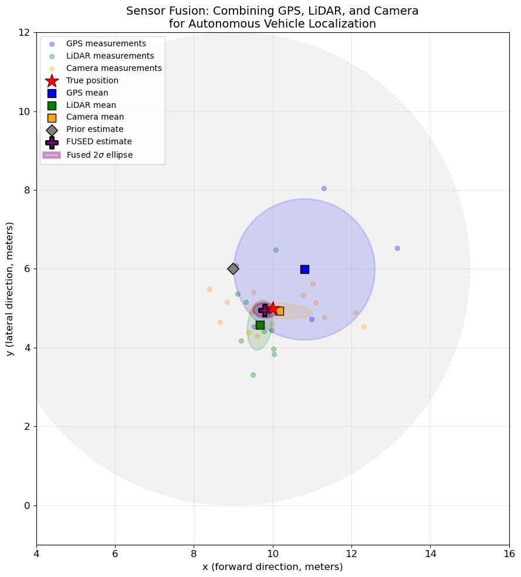

```python
fig, ax = plt.subplots(figsize=(12, 10))

# Plot all measurements (faded)
ax.scatter(y_gps[:, 0], y_gps[:, 1], c='blue', alpha=0.3, s=30, label='GPS measurements')
ax.scatter(y_lidar[:, 0], y_lidar[:, 1], c='green', alpha=0.3, s=30, label='LiDAR measurements')
ax.scatter(y_camera[:, 0], y_camera[:, 1], c='orange', alpha=0.3, s=30, label='Camera measurements')

# Plot true position
ax.scatter(*z_true, s=300, c='red', marker='*', zorder=10, label='True position', edgecolors='darkred')

# Plot individual sensor means with their uncertainty ellipses
colors = ['blue', 'green', 'orange']
names = ['GPS', 'LiDAR', 'Camera']
means = [y_bar_gps, y_bar_lidar, y_bar_camera]
covs = [Sigma_gps/n_gps, Sigma_lidar/n_lidar, Sigma_camera/n_camera]

for name, mean, cov, color in zip(names, means, covs, colors):
    ax.scatter(*mean, s=100, c=color, marker='s', edgecolors='black', linewidth=1,
               label=f'{name} mean', zorder=6)
    plot_covariance_ellipse(ax, mean, cov, n_std=2.0,
                           facecolor=color, alpha=0.15, edgecolor=color, linewidth=2)

# Plot prior
ax.scatter(*mu_prior, s=100, c='gray', marker='D', edgecolors='black', linewidth=1,
           label='Prior estimate', zorder=6)
plot_covariance_ellipse(ax, mu_prior, Sigma_prior, n_std=2.0,
                       facecolor='gray', alpha=0.1, edgecolor='gray', linewidth=2, linestyle=':')

# Plot fused estimate with uncertainty
ax.scatter(*mu_fused, s=200, c='purple', marker='P', edgecolors='black', linewidth=2,
           label='FUSED estimate', zorder=8)
plot_covariance_ellipse(ax, mu_fused, Sigma_fused, n_std=2.0,
                       facecolor='purple', alpha=0.3, edgecolor='purple', linewidth=3,
                       label='Fused 2$\\sigma$ ellipse')

ax.set_xlabel('x (forward direction, meters)', fontsize=12)
ax.set_ylabel('y (lateral direction, meters)', fontsize=12)
ax.set_title('Sensor Fusion: Combining GPS, LiDAR, and Camera\nfor Autonomous Vehicle Localization', fontsize=14)
ax.legend(loc='upper left', fontsize=10)
ax.set_xlim(4, 16)
ax.set_ylim(-1, 12)
ax.set_aspect('equal')
ax.grid(True, alpha=0.3)

plt.tight_layout()
plt.show()
```

## Understanding the Fusion: Precision Weighting

The key insight is that sensor fusion works by **adding precisions** (inverse covariances). Let's visualize how each sensor contributes to the final estimate.

```python
# Compute precision matrices
Lambda_prior = linalg.inv(Sigma_prior)
Lambda_gps = n_gps * linalg.inv(Sigma_gps)
Lambda_lidar = n_lidar * linalg.inv(Sigma_lidar)
Lambda_camera = n_camera * linalg.inv(Sigma_camera)
Lambda_total = Lambda_prior + Lambda_gps + Lambda_lidar + Lambda_camera

# Compute effective weights (contribution to total precision)
def precision_contribution(Lambda_sensor, Lambda_total):
    """Compute the relative contribution of a sensor to total precision."""
    # Use trace as a scalar measure of precision
    return np.trace(Lambda_sensor) / np.trace(Lambda_total) * 100

print("=== PRECISION ANALYSIS ===")
print("\nPrecision matrices (inverse covariance, weighted by n_samples):")
print(f"\nPrior precision trace: {np.trace(Lambda_prior):.2f}")
print(f"GPS precision trace (n={n_gps}): {np.trace(Lambda_gps):.2f}")
print(f"LiDAR precision trace (n={n_lidar}): {np.trace(Lambda_lidar):.2f}")
print(f"Camera precision trace (n={n_camera}): {np.trace(Lambda_camera):.2f}")
print(f"Total precision trace: {np.trace(Lambda_total):.2f}")

print("\n--- Relative Contributions ---")
contributions = {
    'Prior': precision_contribution(Lambda_prior, Lambda_total),
    'GPS': precision_contribution(Lambda_gps, Lambda_total),
    'LiDAR': precision_contribution(Lambda_lidar, Lambda_total),
    'Camera': precision_contribution(Lambda_camera, Lambda_total)
}

for name, contrib in contributions.items():
    print(f"{name}: {contrib:.1f}%")
```

```
=== PRECISION ANALYSIS ===

Precision matrices (inverse covariance, weighted by n_samples):

Prior precision trace: 0.22
GPS precision trace (n=5): 2.50
LiDAR precision trace (n=10): 52.08
Camera precision trace (n=15): 110.83
Total precision trace: 165.64

--- Relative Contributions ---
Prior: 0.1%
GPS: 1.5%
LiDAR: 31.4%
Camera: 66.9%
```

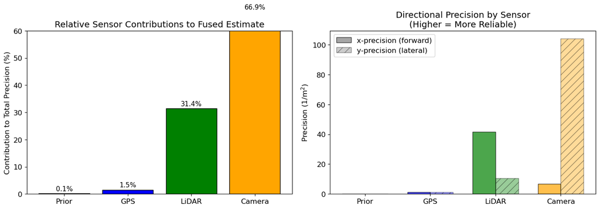

```python
# Visualize contributions
fig, axes = plt.subplots(1, 2, figsize=(14, 5))

# Left: Bar chart of contributions
ax = axes[0]
colors = ['gray', 'blue', 'green', 'orange']
bars = ax.bar(contributions.keys(), contributions.values(), color=colors, edgecolor='black')
ax.set_ylabel('Contribution to Total Precision (%)')
ax.set_title('Relative Sensor Contributions to Fused Estimate')
ax.set_ylim(0, 60)
for bar, val in zip(bars, contributions.values()):
    ax.text(bar.get_x() + bar.get_width()/2, bar.get_height() + 1,
            f'{val:.1f}%', ha='center', fontsize=11)

# Right: Show directional precision (x vs y)
ax = axes[1]

# Extract x and y precision for each sensor
sensors_data = [
    ('Prior', Lambda_prior, 'gray'),
    ('GPS', Lambda_gps, 'blue'),
    ('LiDAR', Lambda_lidar, 'green'),
    ('Camera', Lambda_camera, 'orange'),
]

x_positions = np.arange(len(sensors_data))
width = 0.35

x_precisions = [s[1][0,0] for s in sensors_data]
y_precisions = [s[1][1,1] for s in sensors_data]
names = [s[0] for s in sensors_data]
colors = [s[2] for s in sensors_data]

bars1 = ax.bar(x_positions - width/2, x_precisions, width, label='x-precision (forward)',
               color=[c for c in colors], alpha=0.7, edgecolor='black')
bars2 = ax.bar(x_positions + width/2, y_precisions, width, label='y-precision (lateral)',
               color=[c for c in colors], alpha=0.4, edgecolor='black', hatch='//')

ax.set_xticks(x_positions)
ax.set_xticklabels(names)
ax.set_ylabel('Precision (1/m$^2$)')
ax.set_title('Directional Precision by Sensor\n(Higher = More Reliable)')
ax.legend()

plt.tight_layout()
plt.show()
```

## Anisotropic Fusion: The Power of Complementary Sensors

Notice how the **fused uncertainty ellipse is much smaller than any individual sensor's ellipse**. This is because:

1. **LiDAR** provides high precision in the x-direction (forward)
2. **Camera** provides high precision in the y-direction (lateral)
3. When combined, we get high precision in BOTH directions!

This is the power of **heterogeneous sensor fusion**: sensors with complementary strengths combine to produce an estimate better than any single sensor could achieve.

```python
# Compare uncertainties
print("=== UNCERTAINTY COMPARISON ===")
print("\nStandard deviations (meters):")
print(f"{'Sensor':<15} {'sigma_x':>10} {'sigma_y':>10} {'Area*':>12}")
print("-" * 50)

def ellipse_area(Sigma):
    """Area of 1-sigma ellipse: pi * sqrt(det(Sigma))"""
    return np.pi * np.sqrt(linalg.det(Sigma))

comparisons = [
    ('Prior', Sigma_prior),
    ('GPS (mean)', Sigma_gps/n_gps),
    ('LiDAR (mean)', Sigma_lidar/n_lidar),
    ('Camera (mean)', Sigma_camera/n_camera),
    ('FUSED', Sigma_fused)
]

for name, Sigma in comparisons:
    sx = np.sqrt(Sigma[0,0])
    sy = np.sqrt(Sigma[1,1])
    area = ellipse_area(Sigma)
    print(f"{name:<15} {sx:>10.3f} {sy:>10.3f} {area:>12.4f}")

print("\n* Area of 1-sigma uncertainty ellipse (m^2)")
print(f"\nUncertainty reduction (fused vs best single sensor):")
best_single = min(ellipse_area(Sigma_gps/n_gps),
                  ellipse_area(Sigma_lidar/n_lidar),
                  ellipse_area(Sigma_camera/n_camera))
fused_area = ellipse_area(Sigma_fused)
print(f"Best single sensor area: {best_single:.4f} m^2")
print(f"Fused area: {fused_area:.4f} m^2")
print(f"Improvement: {100*(best_single - fused_area)/best_single:.1f}%")
```

```
=== UNCERTAINTY COMPARISON ===

Standard deviations (meters):
Sensor             sigma_x    sigma_y        Area*
--------------------------------------------------
Prior                3.000      3.000      28.2743
GPS (mean)           0.894      0.894       2.5133
LiDAR (mean)         0.158      0.316       0.1539
Camera (mean)        0.408      0.103       0.1257
FUSED                0.142      0.093       0.0415

* Area of 1-sigma uncertainty ellipse (m^2)

Uncertainty reduction (fused vs best single sensor):
Best single sensor area: 0.1257 m^2
Fused area: 0.0415 m^2
Improvement: 67.0%
```

## Sequential Sensor Fusion

In practice, measurements arrive sequentially. Let's visualize how the estimate improves as we add each sensor.

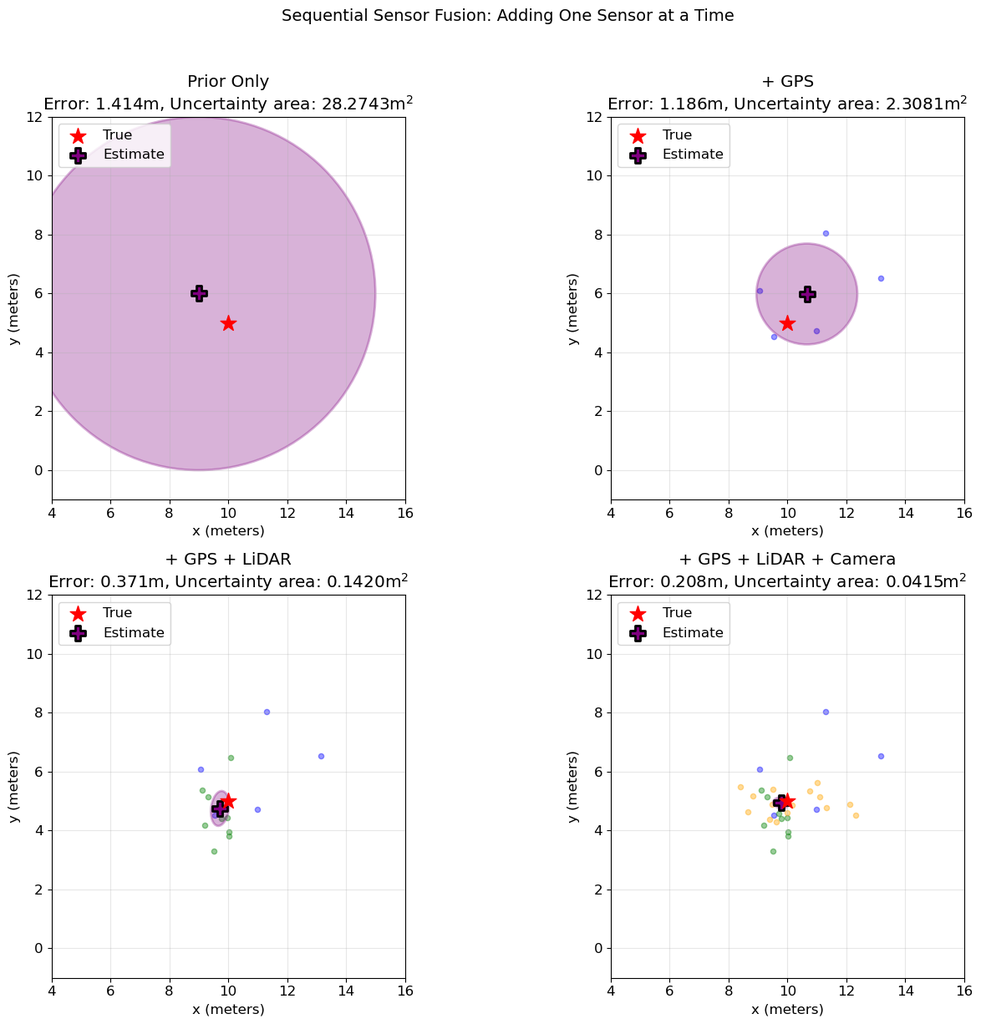

```python
fig, axes = plt.subplots(2, 2, figsize=(14, 12))
axes = axes.flatten()

# Stage 0: Prior only
stages = [
    ('Prior Only', mu_prior, Sigma_prior, []),
]

# Stage 1: Prior + GPS
mu1, Sigma1 = sensor_fusion(mu_prior, Sigma_prior, [y_gps], [Sigma_gps])
stages.append(('+ GPS', mu1, Sigma1, [('GPS', y_gps, 'blue')]))

# Stage 2: Prior + GPS + LiDAR
mu2, Sigma2 = sensor_fusion(mu_prior, Sigma_prior, [y_gps, y_lidar], [Sigma_gps, Sigma_lidar])
stages.append(('+ GPS + LiDAR', mu2, Sigma2, [('GPS', y_gps, 'blue'), ('LiDAR', y_lidar, 'green')]))

# Stage 3: All sensors
stages.append(('+ GPS + LiDAR + Camera', mu_fused, Sigma_fused,
               [('GPS', y_gps, 'blue'), ('LiDAR', y_lidar, 'green'), ('Camera', y_camera, 'orange')]))

for ax, (title, mu, Sigma, sensor_data) in zip(axes, stages):
    # Plot true position
    ax.scatter(*z_true, s=200, c='red', marker='*', zorder=10, label='True')

    # Plot measurements
    for name, measurements, color in sensor_data:
        ax.scatter(measurements[:, 0], measurements[:, 1], c=color, alpha=0.4, s=20)

    # Plot current estimate
    ax.scatter(*mu, s=150, c='purple', marker='P', edgecolors='black', linewidth=2,
               label='Estimate', zorder=8)
    plot_covariance_ellipse(ax, mu, Sigma, n_std=2.0,
                           facecolor='purple', alpha=0.3, edgecolor='purple', linewidth=2)

    # Compute error
    error = linalg.norm(mu - z_true)
    area = ellipse_area(Sigma)

    ax.set_xlabel('x (meters)')
    ax.set_ylabel('y (meters)')
    ax.set_title(f'{title}\nError: {error:.3f}m, Uncertainty area: {area:.4f}m$^2$')
    ax.set_xlim(4, 16)
    ax.set_ylim(-1, 12)
    ax.set_aspect('equal')
    ax.grid(True, alpha=0.3)
    ax.legend(loc='upper left')

plt.suptitle('Sequential Sensor Fusion: Adding One Sensor at a Time', fontsize=14, y=1.02)
plt.tight_layout()
plt.show()
```

## Effect of Sensor Reliability

What happens if one sensor becomes unreliable (e.g., GPS jamming, camera obscured)? The fusion framework naturally handles this by down-weighting unreliable sensors.

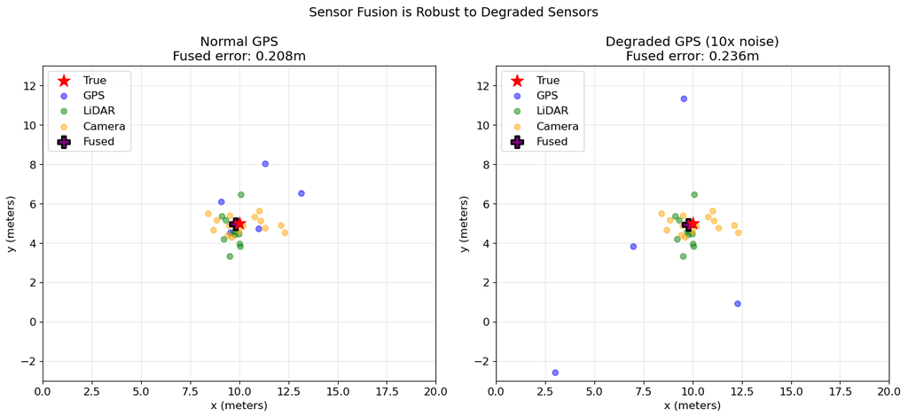

```
With degraded GPS, the fusion still works well because:
1. The degraded GPS has lower precision, so it contributes less
2. LiDAR and Camera still provide reliable information

GPS contribution (normal): 1.5%
GPS contribution (degraded): 0.2%
```

```python
# Simulate degraded GPS (e.g., urban canyon, multipath)
Sigma_gps_degraded = Sigma_gps * 10  # 10x worse

# Regenerate GPS measurements with degraded accuracy
y_gps_degraded = generate_measurements(z_true, Sigma_gps_degraded, n_gps)

# Fusion with degraded GPS
mu_degraded, Sigma_degraded = sensor_fusion(
    mu_prior, Sigma_prior,
    [y_gps_degraded, y_lidar, y_camera],
    [Sigma_gps_degraded, Sigma_lidar, Sigma_camera]
)

# Fusion with normal GPS
mu_normal, Sigma_normal = sensor_fusion(
    mu_prior, Sigma_prior,
    [y_gps, y_lidar, y_camera],
    [Sigma_gps, Sigma_lidar, Sigma_camera]
)

fig, axes = plt.subplots(1, 2, figsize=(14, 6))

for ax, (title, gps_data, gps_cov, mu_est, Sigma_est) in zip(axes, [
    ('Normal GPS', y_gps, Sigma_gps, mu_normal, Sigma_normal),
    ('Degraded GPS (10x noise)', y_gps_degraded, Sigma_gps_degraded, mu_degraded, Sigma_degraded)
]):
    # Plot true position
    ax.scatter(*z_true, s=200, c='red', marker='*', zorder=10, label='True')

    # Plot measurements
    ax.scatter(gps_data[:, 0], gps_data[:, 1], c='blue', alpha=0.5, s=40, label='GPS')
    ax.scatter(y_lidar[:, 0], y_lidar[:, 1], c='green', alpha=0.5, s=40, label='LiDAR')
    ax.scatter(y_camera[:, 0], y_camera[:, 1], c='orange', alpha=0.5, s=40, label='Camera')

    # Plot fused estimate
    ax.scatter(*mu_est, s=150, c='purple', marker='P', edgecolors='black', linewidth=2,
               label='Fused', zorder=8)
    plot_covariance_ellipse(ax, mu_est, Sigma_est, n_std=2.0,
                           facecolor='purple', alpha=0.3, edgecolor='purple', linewidth=2)

    error = linalg.norm(mu_est - z_true)
    ax.set_xlabel('x (meters)')
    ax.set_ylabel('y (meters)')
    ax.set_title(f'{title}\nFused error: {error:.3f}m')
    ax.set_xlim(0, 20)
    ax.set_ylim(-3, 13)
    ax.set_aspect('equal')
    ax.grid(True, alpha=0.3)
    ax.legend(loc='upper left')

plt.suptitle('Sensor Fusion is Robust to Degraded Sensors', fontsize=14, y=1.02)
plt.tight_layout()
plt.show()

print("\nWith degraded GPS, the fusion still works well because:")
print("1. The degraded GPS has lower precision, so it contributes less")
print("2. LiDAR and Camera still provide reliable information")
print(f"\nGPS contribution (normal): {precision_contribution(Lambda_gps, Lambda_total):.1f}%")
print(f"GPS contribution (degraded): {precision_contribution(n_gps * linalg.inv(Sigma_gps_degraded), Lambda_total):.1f}%")
```

## Key Takeaways

### From Chapter 3.3.5: Sensor Fusion

1. **Precision Addition**: When fusing Gaussian measurements, we add **precisions** (inverse covariances), not covariances. This means more reliable sensors naturally contribute more.
2. **Complementary Sensors**: Sensors with different error characteristics can combine to give an estimate better than any individual sensor. LiDAR's x-accuracy + Camera's y-accuracy = excellent overall accuracy.
3. **Graceful Degradation**: If one sensor becomes unreliable (high noise), its precision decreases, and it automatically contributes less to the fused estimate.
4. **The Formulas**:
   - Posterior precision: $\boldsymbol{\Sigma}_{z|y}^{-1} = \boldsymbol{\Sigma}_z^{-1} + \sum_m N_m \boldsymbol{\Sigma}_m^{-1}$
   - Posterior mean: $\boldsymbol{\mu}_{z|y} = \boldsymbol{\Sigma}_{z|y} \left[ \boldsymbol{\Sigma}_z^{-1} \boldsymbol{\mu}_z + \sum_m \boldsymbol{\Sigma}_m^{-1} (N_m \bar{\mathbf{y}}_m) \right]$

### Real-World Applications

This exact technique is used in:

- **Autonomous vehicles**: Fusing GPS, LiDAR, radar, cameras, IMU
- **Robotics**: SLAM (Simultaneous Localization and Mapping)
- **Aviation**: Sensor fusion in flight management systems
- **Smartphones**: Fusing GPS, WiFi, cellular, and accelerometer for location